```python
import numpy as np
import matplotlib.pyplot as plt
from IPython.display import display, Image
from PIL import Image as PILImage
from io import BytesIO

def notebook_dp_image(path: str, dim: set) -> None:
    img = PILImage.open(path)
    resized_img = img.resize(dim)  # (Width, Height)
    buffer = BytesIO()
    resized_img.save(buffer, format='PNG')
    display(Image(data=buffer.getvalue()))
```

*p188~226까지*

# 학습 관련 기술들

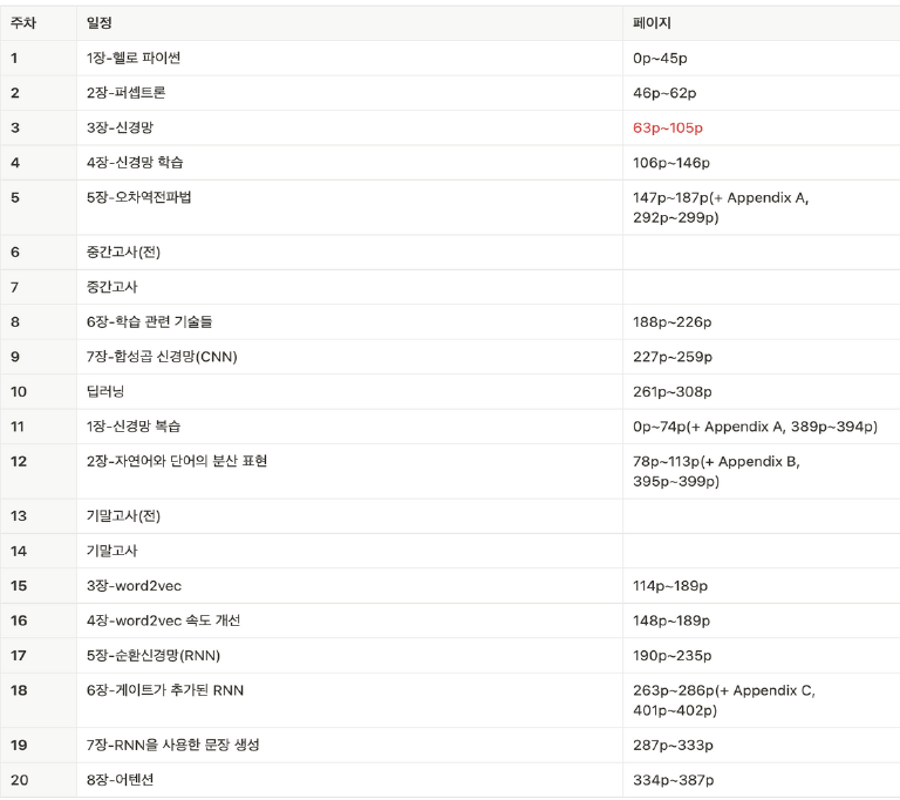

```python
notebook_dp_image('./images/curriculum.png', (900,800))
```

### 별도의 `optmizer` 클래스 만들기

```python
from custom.w5_funcs import *

class SGD:
    def __init__(self, lr=.01):
        self.lr = lr

    def update(self, params, grads):
        for key in params.keys():
            params[key] -= self.lr * grads[key]

(x_train, t_train), (x_test, t_test) = get_dataset()
```

[output not shown]

```python
network = TwoLayerNet(input_size=784, hidden_size=50, output_size=10)
optimizer = SGD()

iters_num = 10000
train_size = x_train.shape[0]
batch_size = 100
learning_rate = 0.1

train_loss_list = []
train_acc_list = []
test_acc_list = []

iter_per_epoch = max(train_size / batch_size, 1)

for i in range(iters_num):
    batch_mask = np.random.choice(train_size, batch_size)
    x_batch = x_train[batch_mask]
    t_batch = t_train[batch_mask]

    # 기울기 계산
    # grad = network.numerical_gradient(x_batch, t_batch) # 수치 미분 방식
    grad = network.gradient(x_batch, t_batch) # 오차역전파법 방식(훨씬 빠르다)

    # 갱신
    '''
    # 일반 매개변수 갱신 방식
    for key in ('W1', 'b1', 'W2', 'b2'):
        network.params[key] -= learning_rate * grad[key]
    '''
    # 별도 optimizer 적용 시
    optimizer.update(network.params, grad)

    loss = network.loss(x_batch, t_batch)
    train_loss_list.append(loss)

    if i % iter_per_epoch == 0:
        train_acc = network.accuracy(x_train, t_train)
        test_acc = network.accuracy(x_test, t_test)
        train_acc_list.append(train_acc)
        test_acc_list.append(test_acc)
        print(f'train acc: {train_acc},\ntest acc: {test_acc}\n', '='*10)
```

```
train acc: 0.08361666666666667,
test acc: 0.08
 ==========
train acc: 0.55985,
test acc: 0.568
 ==========
train acc: 0.78445,
test acc: 0.7917
 ==========
train acc: 0.84835,
test acc: 0.8543
 ==========
train acc: 0.87,
test acc: 0.8748
 ==========
train acc: 0.88355,
test acc: 0.8871
 ==========
train acc: 0.8915666666666666,
test acc: 0.8935
 ==========
train acc: 0.8968666666666667,
test acc: 0.8988
 ==========
train acc: 0.901,
test acc: 0.904
 ==========
train acc: 0.9042833333333333,
test acc: 0.9063
 ==========
train acc: 0.9067333333333333,
test acc: 0.9099
 ==========
train acc: 0.9089833333333334,
test acc: 0.9132
 ==========
train acc: 0.9114,
test acc: 0.9164
 ==========
train acc: 0.9124333333333333,
test acc: 0.9167
 ==========
train acc: 0.91565,
test acc: 0.919
 ==========
train acc: 0.9171833333333334,
test acc: 0.9213
 ==========
train acc: 0.91925,
test acc: 0.9225
 ==========
```

### Momentum

note: stochastic인지 (mini)batch인지 언급이 안되었지만 매 epoch마다 update를 하므로 stachastic임, 단지 어떤 방식으로 진행되는지가 다름

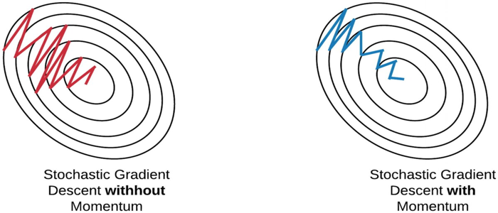

```python
notebook_dp_image('./images/W8/SGD-MOM.jpg', (700,300))
```

운동량/관성 사용하면 전체적 '지형'의 큰 흐름/경사를 알 수 있음. oscillation이 있어도 최저점으로 향한 가속도가 붙게되니 흐를 수 있음.

```python
class Momentum:
    def __init__(self, lr=0.01, momentum=0.9):
        self.lr = lr
        self.momentum = momentum
        self.v = None

    def update(self, params, grads):
        if self.v is None:
            self.v = {}
            for key, val in params.items():
                self.v[key] = np.zeros_like(val)

        for key in params.keys():
            self.v[key] = self.momentum*self.v[key] - self.lr*grads[key]
            params[key] += self.v[key]
```

### AdaGrad

\begin{align*} g_t &= \nabla_{\theta} J(\theta_t) \\ G_t &= G_{t-1} + g_t^2 \\ \theta_{t+1} &= \theta_t - \frac{\eta}{\sqrt{G_t + \varepsilon}} \cdot g_t \end{align*}

- $g_t$: $t$에서의 경사
- $G_t$: 과거 경사들의 제곱합 (element-wise)
- $η$: 초기 LR
- $ε$: 0분할 방지용 엡실론
- $θ_t$: $t$에서의 매개변수

경사가 계속 가파른 경향을 보이면(속도가 크면) 갈수록 LR을 줄이고 그 반대도 어느정도 적용되는 형태

안정적이지만 오래 진행될수록 LR가 decay될 수도 있음

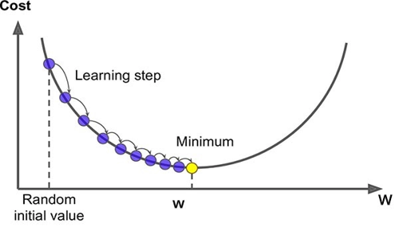

```python
notebook_dp_image('./images/W8/ada.jpg', (500,300))
```

```python
class AdaGrad:
    def __init__(self, lr=0.01):
        self.lr = lr
        self.h = None

    def update(self, params, grads):
        if self.h is None:
            self.h = {}
            for key, val in params.items():
                self.h[key] = np.zeros_like(val)

        for key in params.keys():
            self.h[key] += grads[key] * grads[key]
            params[key] -= self.lr * grads[key] / (np.sqrt(self.h[key]) + 1e-7)
```

### Adam

**TLDR;**

AdaGrad + Momentum

```python
class Adam:

    def __init__(self, lr=0.001, beta1=0.9, beta2=0.999):
        self.lr = lr
        self.beta1 = beta1
        self.beta2 = beta2
        self.iter = 0
        self.m = None
        self.v = None

    def update(self, params, grads):
        if self.m is None:
            self.m, self.v = {}, {}
            for key, val in params.items():
                self.m[key] = np.zeros_like(val)
                self.v[key] = np.zeros_like(val)

        self.iter += 1
        lr_t  = self.lr * np.sqrt(1.0 - self.beta2**self.iter) / (1.0 - self.beta1**self.iter)

        for key in params.keys():
            #self.m[key] = self.beta1*self.m[key] + (1-self.beta1)*grads[key]
            #self.v[key] = self.beta2*self.v[key] + (1-self.beta2)*(grads[key]**2)
            self.m[key] += (1 - self.beta1) * (grads[key] - self.m[key])
            self.v[key] += (1 - self.beta2) * (grads[key]**2 - self.v[key])

            params[key] -= lr_t * self.m[key] / (np.sqrt(self.v[key]) + 1e-7)
```

## 가중치들의 초기값

어떻게 DNN의 weight들을 초기화하는지?

(ReLU NN을 예시로 했을때)

**그냥 한 값(0)으로 통일하기**

- 여러 은닉층을 만들어도 값이 다 같으니 레이어나 노드 하나로 되있는 NN이랑 다를게 없어짐 - 학습이 안됨.

**정규분포대로 주기**

- 표준정규분포일 경우 범위가 좀 넓어서 층별 output이 0 아니면 1로 값이 몰릴 가능성이 있다. 그런다면 기울기소실(gradient vanish)이 일어나서 학습이 잘 안될 수 있음. 대부분 0에 솔려있으면 다음 layer로 넘어갈때 거의 다 0으로 나와서 그 이후로는 죄다 0만 출력되어버림.
- (작은 분포의)정규분포일 경우 기울기소실은 안일어날수도 있지만 위의 한 값으로 통일한것과 거의 비슷하게 되어서 표현력이 크게 줄어들 수 있음.
- 결론적으로 분포를 작게하든 크게하든 문제가 있을꺼임

### Xavier 초깃값

TLDR; $$ \text{한 층의 표준편차}=\sqrt{\frac{1}{n}} \\ (n=\text{앞 층의 노드 수}) $$

레이어별 표준편차를 달리해서 뒤로갈수록 좁게, 앞으로 갈수록 넓게(1을 향해서?)

### He 초깃값

$$ \text{한 층의 표준편차}=\sqrt{\frac{2}{n}} \\ (n=\text{앞 층의 노드 수}) $$

Xavier에서 더 넓게 분포시키기 위해 2x

사용 목적으로 본다면 다음과 같은 특징을 가지고 있음, 둘 다 기본적인 동작 개념은 비슷함.

> - He initialization works better for layers with ReLu activation.
> - Xavier initialization works better for layers with sigmoid activation.

## Batch normalization

직관적인 관점으로 바라봤을때:

각 층에서의 아웃풋은 인풋이 고르게 분포되어서 들어와도 skew되어서 나오거나 좁게/넓게 분포되어 나올 수 있다. 이럴 경우 훈련을 하는데 어려움을 겪을 수 있는데, batch norm은 각 레이어 거칠때마다 값을 정규화해줘서 더 쉬게 training이 될 수 있도록 도와준다.

**note*: 나중에 나올 (training에만 쓰이는)가중치 감소와 드롭아웃과 달리 Batch norm은 training과 inference모두 사용이 된다. 그래서 별개로 붙은 실제 레이어로 취급이 됨. (물론 당연하게 보일수도 있겠지만)*

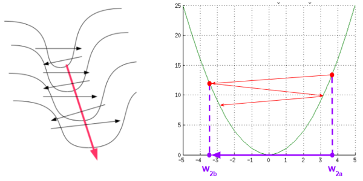

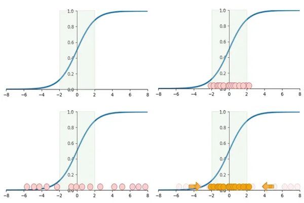

```python
notebook_dp_image('./images/W8/batch_norm2.jpg', (600,300))
notebook_dp_image('./images/W8/batch_norm.jpg', (600,400))
```

위의 1번째 그림은 각 레이어를 거칠때마다 진행되는 grad. desc.를 보여주는데, 층별 데이터 분포가 오른쪽으로 넓어져서 모델이 학습을 할수록 크게 값조정을 해야하는 것이 보인다. 이는 모델 훈련할때 시간이 오래 걸리게 하고 또 불안정하게도 만든다.

2번째 그림은 한 레이어에서 다음 레이어로 넘어갈 때 정규화하는 과정을 보여준다. 넓게 퍼지기 시작하는 값들을 다시 안정화(표준정규분포로)해줌으로서 경사가 불아정해지거나 평탄해지는 것을 방지해준다.

## 과대적합 (과적합/오버피팅) 방지

### 가중치 감소 (weight decay)

**TLDR;**

큰 매개변수값에 대하여 큰 페널티를 부과한다.

$$ \text{Loss}_{\text{total}} = \text{Loss}_{\text{data}} + \lambda \|\theta\|_2^2 $$

이 페널티를 loss에 더해서 최종 loss를 내놓는다. 이렇게 하면 오버피팅의 가장 대표적인 결과인 매개변수 집중/비대화를 막을 수 있다. 일종의 threshold역할 같다.

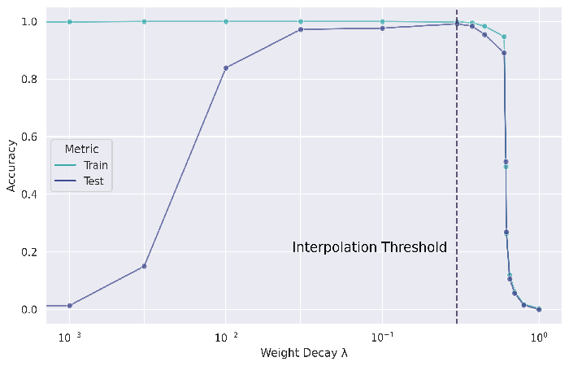

```python
notebook_dp_image('./images/W8/weight_decay_v.jpg', (700,450))
```

### 드롭아웃 (dropout)

말 그대로 훈련 중간에 무작위로 dropout ratio만큼 레이어별로 노드를 비활성화 시킨다. (inference시에는 다시 다 켜줌)

이 방식은 어떤 레이어나 어떤 노드의 값에 모델이 결과를 과의존하는 것을 방지해준다. (이 또한 과적합의 흔한 현상)

사람으로 비유하자면 어떤 작업하는데 시각에 너무 많이 의존한다 싶으면 눈 가려버리고 촉각이나 후각 등으로 작업하는것을 훈련하는거. 실제로 일하때는 안대 풀어주고...

이렇게 하면 선택적으로 특정노드들을 고르게 강화시킬 수 있다는 장점 있음. 물론 훈련시간은 길어짐. 개념적으로 그리고 적용하기에도 크게 어렵진 않은 최적화.

## Hyperparameter 최적화

hyperparameter는 훈련을 위한 매개변수랄까...

LR, dropout ratio, decay rate, initalization val. 등의 지금가지 weight/bias 외의 변수들. 지금까지는 수동으로 해왔지만 이거 또한 자동으로(?) 최적화가 가능.

대부분 무작위 형태로 진행이 됨. (더 결과가 잘나온다고 함) 그렇게 진행하다 점점 탐색 범위를 좁혀가는 식.

각 hyperparam. epoch별 일반 train을 다 해야하니 꽤나 오래 걸리는 과정임. 훈련을 위한 훈련을 계속 한달까...

아래의 그림은 hyperparam설정 전략 (대부분 random과 adaptive의 혼합으로 사용, 그게 결과가 젤 잘나온다고 한다.)

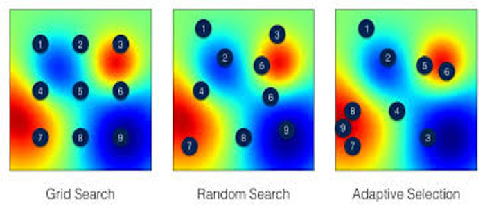

```python
notebook_dp_image('./images/W8/hyperparam.jpg', (700,300))
```